# Patterns in Payments: A Data Driven Look at day-to-day transactions

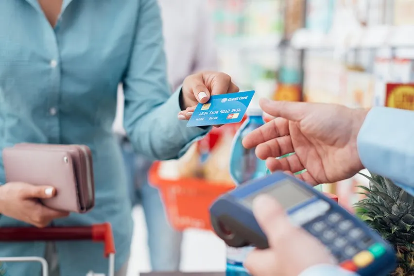

## A Brief overview of my Data Story

We all make transactions every day, whether it is buying a bottle of milk or paying your school fees. But have you ever thought about how these everyday exchanges could be visualized to reveal patterns and insights? Not just for personal interest, but also to inform businesses and shop owners. That is the focus of my data story.

Over the past few months, I have been observing and recording a variety of transactions across settings like supermarkets, cafes and restaurants, online shopping platforms, public transport, and retail stores. I’ve tracked details such as the transaction amount, payment method, and time of purchase. Data was collected through Google Forms from 29/03/2025 to 31/03/2025 as part of Project 2 and then on 10/05/2025 as part of Project 4, with a series of additional variables to record whether I knew the person making the transaction, whether the person took a receipt and whether they did a self checkout or through a cashier.

Through this data, I aim to explore four key questions using a series of thoughtful and engaging visualizations. The claims that I make are purely based on my observational data and should not be generalized to the larger public.

## What could be the most popular payment method that people prefer these days in different transactional places?

I have created a bar chart to answer this question. The bar chart contains the number of transactions observed for each different mode of payment by each level of transaction place, which includes Credit/Debit cards, Cash, Mobile Payments and Gift Vouchers for the mode of payments and Supermarkets, Cafe/Restaurants, Online Shopping, Retail Stores and Public Transports as the place of transaction.

[figure not shown]

Bar Chart showing number of transactions for each method of payment by transaction place

### Conclusion

We find the following:

- For Supermarkets, the number of transactions done using Cards and Mobile Payments are roughly equal and hence most people used the above two mode of payments when making transactions in Supermarkets.
- For Cafe/Restaurants, the number of transactions done using Cards is the highest and hence most people preferred using Cards over any other mode of payment when making transactions in Cafe/Restaurants.
- For Online Shopping platforms, the number of transactions done using Gift Vouchers and Gift Cards is slightly higher than the ones done using a Card (Debit/Credit), and hence most people preferred to use their Gift Vouchers and Gift Cards when making transactions over online platforms.
- For Retail stores, the number of transactions done using Cash appears to be the highest, and hence most people preferred the traditional way of paying with cash when making transactions in Retail Stores.
- For Public Transports, the number of transactions done using Cards(Debit/Credit) is the highest and hence most people preferred to use Cards when making transactions in Public Transports.
- Overall, the most number of transactions were observed in Supermarkets followed by Cafe/Restaurants.

## What could be the peak hours of the day when most transactions occur?

I have created a line chart to answer this question. The line chart shows the distribution for the number of transactions by each hour of the day.

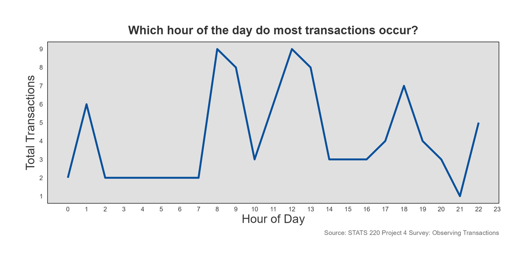

Line chart showing number of transactions by hour of the day

### Conclusion

The peak hours of the day when most transactions occurred in my data are 8 and 12. This is what I had expected as the hour 8 (8 AM) is when most people go to work/school, so we might expect a lot of transactions happening at public transports. The hour 12 (12 PM) is when we expect the peak hours for restaurants and cafes as it is lunch time and also we might expect a lot of people to do their shopping around noon.

## How much do people usually spend in different places?

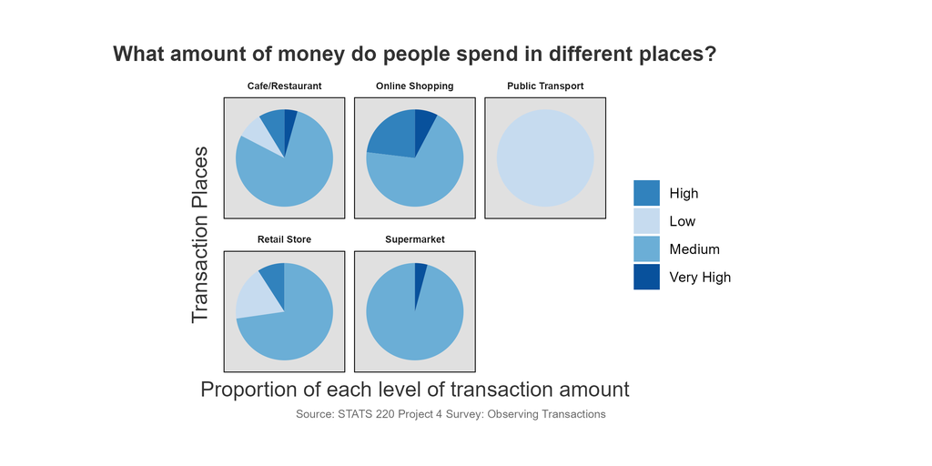

Pie chart showing the level of transaction amount by place

### Conclusion

We find the following:

- People mostly do medium level of spending (between 20 NZD and 100 NZD) in Cafes/Restaurants, Online shopping websites, Retail Stores and Supermarkets.
- We do not expect any people to spend more than 20 NZD in Public Transports, as observed in my data.

## Do people I know generally use self checkout or do they check out through a cashier?

I have decided to go with a bar chart once again to answer this question. I have plotted the number of transactions observed for both completed using a self checkout and a cashier.

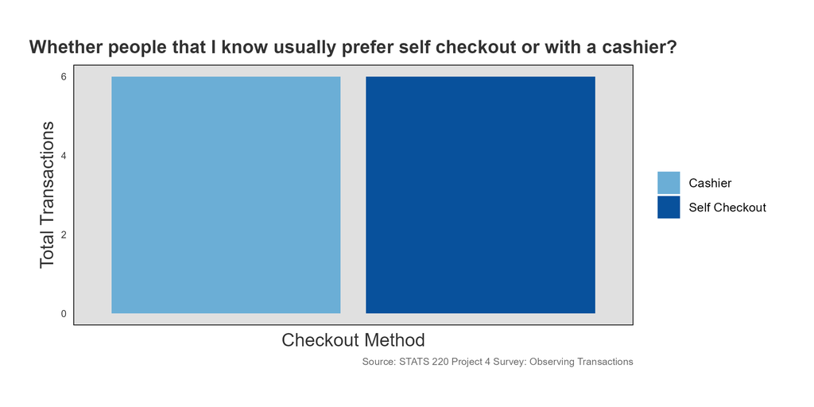

Bar chart showing the number of transactions by checkout type

### Conclusion

For the people that I know, the number of transactions observed for each level of checkout i.e the ones done using a self checkout and the ones with a cashier, is exactly the same as observed from my data. Hence, we cannot say whether people that I know usually prefer self checkouts over cashiers.

## Summary of my Findings

Overall I found :

1. People mostly used Cards(Credit/Debit) as their mode of payment when making Transactions in Supermarkets, Cafe/Restaurants and Public Transports while sticking to the traditional way of paying with cash in Retail Stores. Moreover, people preferred to use Gift Cards and Gift Vouchers when making transactions over Online Shopping Platforms.
2. The peak hours of the day when most transactions were observed are 8 AM and 12 PM.
3. People mostly spent around 20 NZD and 100 NZD in Supermarkets, Cafes/Restaurants, Online Shopping, and Retail Stores, while there was not any transaction over 20 NZD in Public Transports.
4. For the people that I know, there was an equal number of transactions observed, for both done using a self checkout and with a cashier.

### Thank You For Reading My Data Story!

[figure not shown]